# Time Series: A First Course with Bootstrap Starter

# Lesson 4-4: Projection in Hilbert Space

- We further examine projections in Hilbert Spaces.

## Projection on a Linear Space

- We can project one vector onto a linear space spanned by many vectors.
- Let $\mathcal{M} = \mbox{span} \{ \underline{x}_1, \ldots, \underline{x}_p \}$, which is all linear combinations of the $p$ spanning vectors.
- To project $\underline{y}$ onto $\mathcal{M}$, we seek a linear combination $\widehat{\underline{y}}$ of the $p$ spanning vectors, such that $\underline{y} - \widehat{\underline{y}}$ is orthogonal to $\mathcal{M}$, i.e., to each $\underline{x}_i$.

## Projection in ${\mathbb L}_2$

- Suppose we want to project $Y \in {\mathbb L}_2$ onto a subspace $\mathcal{M} \subset {\mathbb L}_2$.
- Suppose the subspace is the span of random variables $X_1, \ldots, X_p$.
- Let $\widehat{Y} \in \mathcal{M}$ be the projection. Then $Y - \widehat{Y}$ is orthogonal to each $X_i$.

## Fact 4.4.2. Orthogonality Principle

- Consider projection in ${\mathbb L}_2$. The distance to the projection $\widehat{Y}$ is $\| Y - \widehat{Y} \|$.
- The *orthogonality principle* states that the distance is minimized if and only if $Y - \widehat{Y}$ is orthogonal to all elements of $\mathcal{M}$.
- So the projection onto a subspace actually minimizes the norm distance to that space.

## Normal Equations

- The condition for projection says that $0 = \langle Y - \widehat{Y}, X_i \rangle$ for $1 \leq i \leq p$.
- These $p$ equations are called the *normal equations*, because they ensure that the error vector $\epsilon = Y - \widehat{Y}$ is orthogonal (i.e., normal) to the subspace.
- So we have to solve $\langle Y, X_i \rangle = \langle \widehat{Y}, X_i \rangle$ for $1 \leq i \leq p$.
- The distance from $Y$ to the subspace is $\| \epsilon \|$.
- In ${\mathbb L}_2$, ${\| \epsilon \| }^2 = {\mathbb E} [ {(Y - \widehat{Y})}^2]$ is the *Mean Squared Error* (MSE).

### Example of Linear Projection in ${\mathbb L}_2$

- We simulate bivariate Gaussian random variables with correlation $\rho$ and variance $1$.
- We can do this by using
  $$\left[ \begin{array}{cc} 1 & \rho \\ \rho & 1 \end{array}
  \right]
  = \left[ \begin{array}{cc} 1 & 0 \\ \rho &\sqrt{1-\rho^2}
  \end{array} \right]
  \left[ \begin{array}{cc} 1 & \rho \\ 0 & \sqrt{1-\rho^2}
  \end{array} \right].$$
- From prior results, the projection of the second variable onto the first is $\rho$ times the first random variable.
- We compute the projection, and plot.

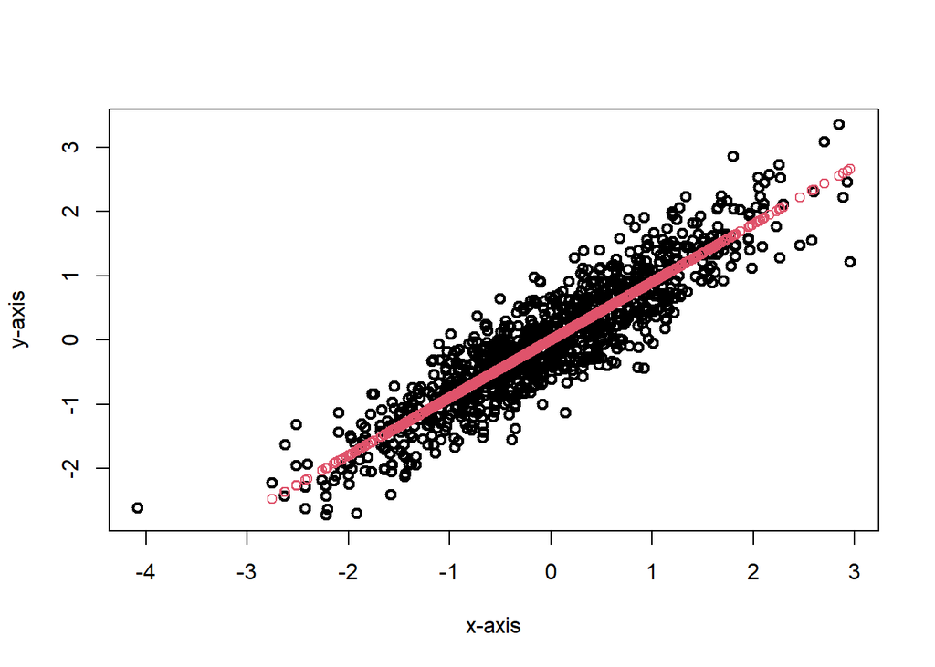

```r
rho <- .9
mat <- matrix(c(1,rho,0,sqrt(1-rho^2)),2,2)
z <- rnorm(2000)
x <- mat %*% matrix(z,2,1000)
plot(x=x[1,],y=x[2,],xlab="x-axis",ylab="y-axis",axes=TRUE,lwd=2)
proj <- rho*x[1,]
points(x=x[1,],y=proj,col=2)
```

- The projection MSE is ${ \| X_2 - \rho X_1 \| }^2 = 1 - \rho^2$.
- We compute the sample variance of the projection errors, and compare to the projection MSE.

```r
print(var(proj-x[2,]))
```

```
## [1] 0.1779577
```

```r
print(1 - rho^2)
```

```
## [1] 0.19
```